# The Impact of Neurobehavior on Feeding Outcomes in Neonates with CHD

Haojia Li

2023-12-03

```r
library(tidyverse)
library(gtsummary)
library(knitr)
library(kableExtra)
# handle missing data
library(VIM) # visualization
library(mice) # imputation

# read in raw data
nnns0 <- read.csv("../NNNS_score_data.csv")
```

## Data cleaning

Data file: “NNNS_score_data.csv”; Data dictionary: “NNNS_score_data_dictionary.xlsx”.

The raw data contains 129 observations and 44 columns. Infants with neurologic or airway anomaly should be excluded from the analysis.

Outcome 1 is the percentage of feeds taken by mouth at discharge, which is bounded by [0,1], with a substantial fraction of the data falling at the boundaries (exactly 0’s and 1’s).

Outcome 2 is the time to achieve full oral feeds after cardiac surgery, which is calculated as the time difference in days between the start date of PO feed and either the date of reaching full PO or the date of “not yet full PO”. Non-missing date of “not yet full PO” indicates censoring.

Besides the predictor, NNNS attention score, the variables of interest include: sex, genetic syndrome, age at surgery in days, prematurity, cardiac anatomy, length of intubation, length of stay, extubation failure and gastrointestinal complications.

The 12 other NNNS scales, pre-op and post-op, are not of interest in this analysis, but could be used as auxiliary variables in the imputation model.

```r
# clean up variable names
# remove the dots at the end of variable names
colnames(nnns0) <- gsub("\\.+$", "", colnames(nnns0))
# replace all the dots in variable names with underscores
colnames(nnns0) <- gsub("\\.+", "_", colnames(nnns0))

# summary of the data
# summary(nnns0)

nnns <- nnns0 |>

  filter(
    # exclude neurologic or airway anomaly
    Neurologic_Complication == 0, AirwayAnomalyYN == 0,
    # include infants from birth to 4 weeks old
    # there are two outliers with age at surgery > 30 days
    Age_at_Surgery_days <= 30
  ) |>

  mutate(

    # some binary variables have values of 1/2 or Y/N, recode them to 0/1
    Female = as.integer(sex_1_M_2_F == 2),
    Premature = as.integer(Premature == 1),
    Extubation_failure = as.integer(Extubation_failure == "Y"),

    # for model building purposes, combine the 2 levels w/o arch obstruction in cardiac anatomy
    Cardiac_Anatomy = factor(case_when(
      Cardiac_Anatomy %in% c(1,3) ~ 1,
      Cardiac_Anatomy == 2 ~ 2,
      Cardiac_Anatomy == 4 ~ 3
    ), levels = 1:3, labels = c("W/o arch obstruction", "Single ventricle w/ arch obstruction", "Two ventricle w/ arch obstruction"))

  ) |>

  # convert date variables to date class
  mutate_at(
    vars("Date_PO_feeds_started", "Date_Reaching_Full_PO", "Date_Identified_as_not_yet_full_PO"),
    as_date, format = "%m/%d/%Y"
  ) |>

  # drop unnecessary variables
  select(!c(
    "sex_1_M_2_F", # use Female instead
    "Intubated_Pre_operatively", "bypass_used", "bypass_time_min", # not of interest
    "Neurologic_Complication", "AirwayAnomalyYN" # already excluded
  ))

# names and labels of variables
dict_nnns <- data.frame(

  name = c(
    # primary outcome
    "Percent_of_feeds_taken_by_mouth_at_discharge",
    # predictor of interest
    "Pre_Op_NNNS_attention_score", "Post_Op_NNNS_attention_score",
    # 8 infant/surgery characteristics
    "Age_at_Surgery_days", "Female",
    "Genetic_Syndrome_or_Chromosomal_Abnormality", "Cardiac_Anatomy",
    "GI_Complication", "Length_of_Stay_days",
    "Length_of_intubation_days", "Extubation_failure",
    # 12 pre-op non-attention NNNS scores
    "Pre_Op_NNNS_habituation_score", "Pre_Op_NNNS_handling_score",
    "Pre_Op_NNNS_Quality_of_Movement_Score", "Pre_Op_NNNS_Regulation_Score",
    "Pre_Op_NNNS_Non_Optimal_Reflexes_Score", "Pre_Op_NNNS_Stress_Score",
    "Pre_Op_NNNS_Arousal_Score", "Pre_Op_NNNS_Hypertonic_Score",
    "Pre_Op_NNNS_Hypotonic_Score", "Pre_Op_NNNS_Asymmetry_Score",
    "Pre_Op_NNNS_Excitability_Score", "Pre_Op_NNNS_Lethargy_Score",
    # 12 post-op non-attention NNNS scores
    "Post_Op_NNNS_habituation_score", "Post_Op_NNNS_handling_score",
    "Post_Op_NNNS_Quality_of_Movement_Score", "Post_Op_NNNS_Regulation_Score",
    "Post_Op_NNNS_Non_Optimal_Reflexes_Score", "Post_Op_NNNS_Stress_Score",
    "Post_Op_NNNS_Arousal_Score", "Post_Op_NNNS_Hypertonic_Score",
    "Post_Op_NNNS_Hypotonic_Score", "Post_Op_NNNS_Asymmetry_Score",
    "Post_Op_NNNS_Excitability_Score", "Post_Op_NNNS_Lethargy_Score"
  ),

  label = c(
    # primary outcome
    "Percentage of oral feed at discharge",
    # predictor of interest
    "Pre-op attention", "Post-op attention",
    # 8 infant/surgery characteristics
    "Age at surgery in days", "Female",
    "Genetic Syndrome / Chromosomal Abnormality", "Cardiac Anatomy",
    "Gastrointestinal Complication", "Length of Stay in days",
    "Length of intubation in days", "Extubation failure",
    # 12 pre-op non-attention NNNS scores
    "Pre-op habituation", "Pre-op handling", "Pre-op quality of movement",
    "Pre-op regulation", "Pre-op non-optimal reflexes", "Pre-op stress",
    "Pre-op arousal", "Pre-op hypertonic", "Pre-op hypotonic",
    "Pre-op asymmetry", "Pre-op excitability", "Pre-op lethargy",
    # 12 post-op non-attention NNNS scores
    "Post-op habituation", "Post-op handling", "Post-op quality of movement",
    "Post-op regulation", "Post-op non-optimal reflexes", "Post-op stress",
    "Post-op arousal", "Post-op hypertonic", "Post-op hypotonic",
    "Post-op asymmetry", "Post-op excitability", "Post-op lethargy"
  ))

# create sets of variables for the convenience of calling them later
basevar <- c(
  "Age_at_Surgery_days", "Female",
  "Genetic_Syndrome_or_Chromosomal_Abnormality", "Cardiac_Anatomy",
  "GI_Complication", "Length_of_Stay_days",
  "Length_of_intubation_days", "Extubation_failure"
)
preop_nnns <- dict_nnns$name[grepl("Pre_Op_NNNS", dict_nnns$name)]
postop_nnns <- dict_nnns$name[grepl("Post_Op_NNNS", dict_nnns$name)]

# function to label variables
label_data <- function(data) {
  colnames(data) <- ifelse(
    colnames(data) %in% dict_nnns$name,
    dict_nnns$label[match(colnames(data), dict_nnns$name)],
    colnames(data)
  )
  return(data)
}
```

## Missing data

There are in total of 30 variables with missing values: percentage of oral feed at discharge, 13 pre-op NNNS scores, 13 post-op NNNS scores, and 3 date variables. The missing values in the date variables are not real missing values, but rather an indication of censoring. There are 5 (4.35%) missing values in the percentage of oral feed at discharge, 60 (52.17%) in pre-op attention score, and 33 (28.70%) in post-op attention score.

```r
# variables with missing data
data.frame(nmiss = colSums(is.na(nnns |> select(-starts_with("Date"))))) |>
  # only keep variables with missing data
  filter(nmiss > 0) |>
  # add percentage
  mutate(perc = round(nmiss / nrow(nnns) * 100, 1)) |>
  # add variable names
  rownames_to_column("variable") |>
  # match variable names with labels
  mutate(variable = dict_nnns$label[match(variable, dict_nnns$name)]) |>
  # sort by percentage
  arrange(desc(perc)) |>
  kable() |>
  kable_styling(bootstrap_options = c("striped", "hover", "condensed", "responsive")) |>
  scroll_box(height = "300px")
```

| variable | nmiss | perc |
| --- | --- | --- |
| Post-op habituation | 85 | 73.9 |
| Pre-op habituation | 83 | 72.2 |
| Pre-op attention | 60 | 52.2 |
| Pre-op handling | 51 | 44.3 |
| Pre-op regulation | 35 | 30.4 |
| Pre-op quality of movement | 34 | 29.6 |
| Pre-op non-optimal reflexes | 34 | 29.6 |
| Pre-op stress | 34 | 29.6 |
| Pre-op arousal | 34 | 29.6 |
| Pre-op hypertonic | 34 | 29.6 |
| Pre-op hypotonic | 34 | 29.6 |
| Pre-op asymmetry | 34 | 29.6 |
| Pre-op excitability | 34 | 29.6 |
| Pre-op lethargy | 34 | 29.6 |
| Post-op attention | 33 | 28.7 |
| Post-op handling | 30 | 26.1 |
| Post-op quality of movement | 24 | 20.9 |
| Post-op regulation | 24 | 20.9 |
| Post-op non-optimal reflexes | 24 | 20.9 |
| Post-op stress | 24 | 20.9 |
| Post-op arousal | 24 | 20.9 |
| Post-op hypertonic | 24 | 20.9 |
| Post-op hypotonic | 24 | 20.9 |
| Post-op asymmetry | 24 | 20.9 |
| Post-op excitability | 24 | 20.9 |
| Post-op lethargy | 24 | 20.9 |
| Percentage of oral feed at discharge | 5 | 4.3 |

### Missing pattern of pre-op and post-op NNNS

We found that the proportion of missing values in attention and handling scores are higher than the others. So we ploted the missing data pattern of all the 12 NNNS scores first, then the plot with attention score excluded, and finally the plot with both attention and handling scores excluded.

The plots show that the missing is consistent scross the 10 NNNS scores (i.e., 13 NNNS scores, excluding habituation, attention, and handling). Except for the only one observation with pre-op regulation missing while others not, there are only 3 situations: (1) all the pre-op and post-op scores are assessed, (2) all the pre-op scores are missing but all the post-op scores are assessed, and (3) all the pre-op scores are assessed but all the post-op scores are missing. This means it is fair to treat these 10 NNNS scores the same when identifying the predictive characteristics of missingness.

In order to incorporate the information of other missing situations, we created a count variable of missing NNNS scores (excluding habituation, attention, and handling).

#### 12 NNNS scores

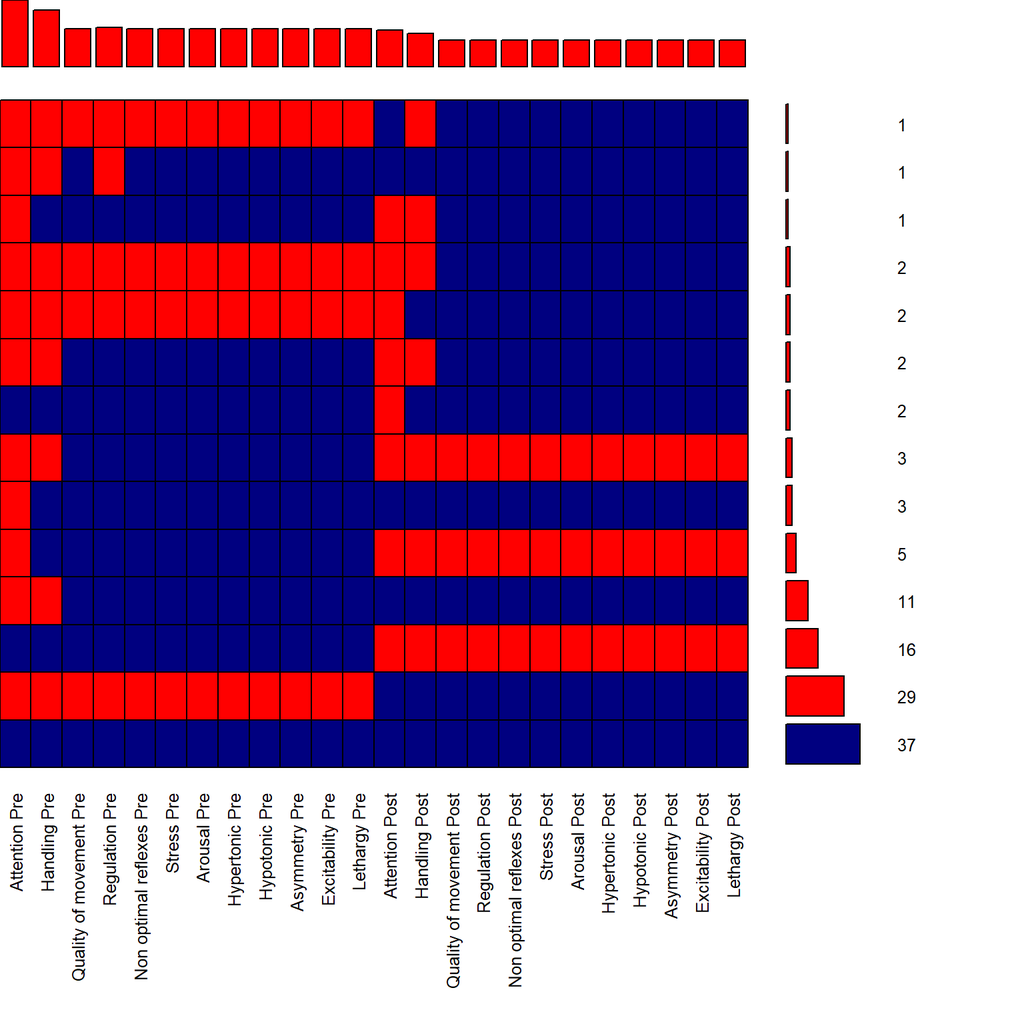

```r
nnns <- nnns |>
  # create indicator of missing pre-op and post-op habituation score
  mutate(
    Pre_Op_habituation_missing = as.integer(is.na(Pre_Op_NNNS_habituation_score)),
    Post_Op_habituation_missing = as.integer(is.na(Post_Op_NNNS_habituation_score))
  ) |>
  # create indicator of missing pre-op and post-op attention score
  mutate(
    Pre_Op_attention_missing = as.integer(is.na(Pre_Op_NNNS_attention_score)),
    Post_Op_attention_missing = as.integer(is.na(Post_Op_NNNS_attention_score))
  ) |>
  # create a count variable of missing NNNS scores
  mutate(
    preop_nnns_missing = rowSums(is.na(pick(preop_nnns))) - Pre_Op_attention_missing - Pre_Op_habituation_missing,
    postop_nnns_missing = rowSums(is.na(pick(postop_nnns))) - Post_Op_attention_missing - Post_Op_habituation_missing
  )

nnns_score <- nnns |> select(preop_nnns, postop_nnns, -contains("habituation"))

# shorten variable names
colnames(nnns_score) <- sapply(
  colnames(nnns_score),
  \(x)
  # remove the "Pre_/Post_Op_NNNS_" prefix and "_score" suffix
  # use nchar("_score") to avoid to distinguish upper and lower case
  str_sub(x, str_locate(x, "NNNS_")[2] + 1, nchar(x) - nchar("_score")) |>
    # capitalize the first letter
    str_to_title() |>
    # replace underscore with space
    str_replace_all("_", " ") |>
    # add 0/1 suffix to indicate pre-op/post-op
    paste(ifelse(str_starts(x, "Post"), "Post", "Pre"))
)

aggr(
  nnns_score,
  col = c("navyblue", "red"), numbers = T, prop = F, sortVars = F, combined = T,
  cex.axis = .8, cex.numbers = .8, oma = c(10,0,0,2)
)
```

#### 11 NNNS scores

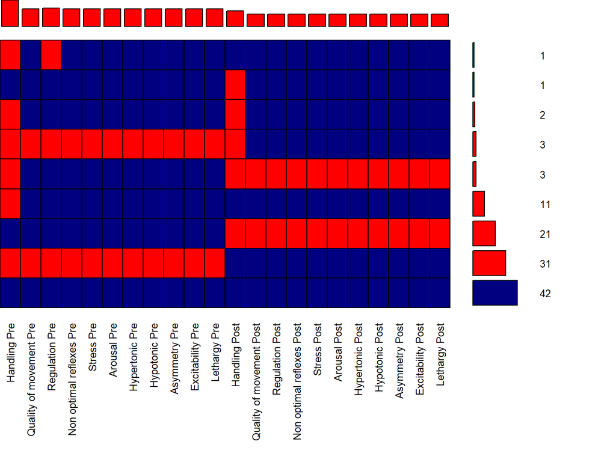

```r
aggr(
  nnns_score |> select(-contains("Attention")),
  col = c("navyblue", "red"), numbers = T, prop = F, sortVars = F, combined = T,
  cex.axis = .8, cex.numbers = .8, oma = c(10,0,0,2)
)
```

#### 10 NNNS scores

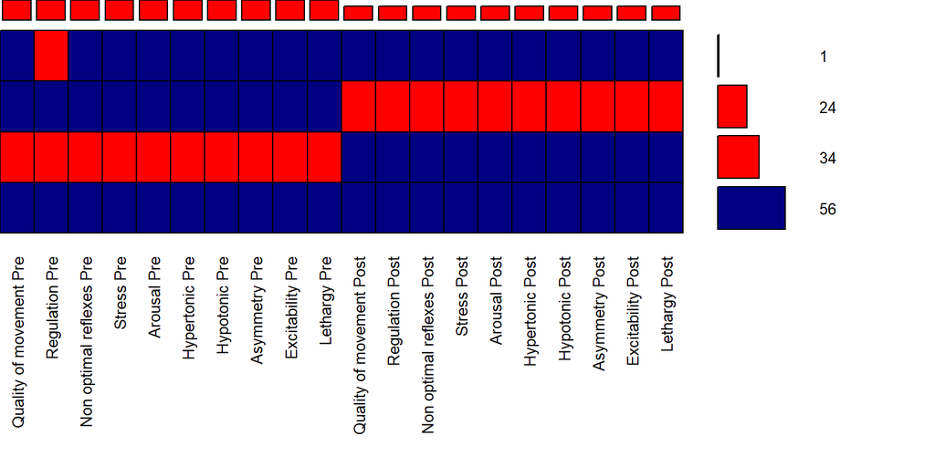

```r
aggr(
  nnns_score |> select(-contains("Attention"), -contains("Handling")),
  col = c("navyblue", "red"), numbers = T, prop = F, sortVars = F, combined = T,
  cex.axis = .8, cex.numbers = .8, oma = c(10,0,0,2)
)
```

### Characteristics distribution by missingness

Given the sample size, we used significance level of 0.1 in the descriptive tables.

#### Percentage of oral feed at discharge

There are 5 (4.35%) missing values in the percentage of oral feed at discharge.

The missingness in percentage of oral feed at discharge is associated with higher risk of GI complication (60% vs 8.2%, p = 0.008), lower post-op stress level (0.02 vs 0.06, p = 0.021), and higher asymmetry (1 vs 0, p = 0.028).

```r
# characteristics disgribution by missing percentage of oral feed at discharge
nnns |>
  mutate(Percent_of_feeds_taken_by_mouth_at_discharge_missing = factor(is.na(Percent_of_feeds_taken_by_mouth_at_discharge), levels = c(F, T), labels = c("Non-missing", "Missing"))) |>
  select(
    all_of(c(basevar, preop_nnns, postop_nnns)),
    Percent_of_feeds_taken_by_mouth_at_discharge_missing
  ) |>
  label_data() |>
  tbl_summary(
    by = Percent_of_feeds_taken_by_mouth_at_discharge_missing,
    type = list(where(\(x) is.numeric(x) & n_distinct(x) > 2) ~ "continuous"),
    missing_text = "Not assessed"
  ) |>
  # add p-values to the table and bold p-values < 0.1
  add_p() |> bold_p(t = 0.1) |>
  modify_caption("Characteristics distribution by missing percentage of oral feed at discharge")
```

Characteristics distribution by missing percentage of oral feed at discharge

| **Characteristic** | **Non-missing**, N = 110<sup>1</sup> | **Missing**, N = 5<sup>1</sup> | **p-value**<sup>2</sup> |
| --- | --- | --- | --- |
| Age at surgery in days | 7 (5, 9) | 5 (5, 11) | 0.8 |
| Female | 42 (38%) | 3 (60%) | 0.4 |
| Genetic Syndrome / Chromosomal Abnormality | 24 (22%) | 0 (0%) | 0.6 |
| Cardiac Anatomy |  |  | 0.7 |
| W/o arch obstruction | 46 (42%) | 2 (40%) |  |
| Single ventricle w/ arch obstruction | 26 (24%) | 2 (40%) |  |
| Two ventricle w/ arch obstruction | 38 (35%) | 1 (20%) |  |
| Gastrointestinal Complication | 9 (8.2%) | 3 (60%) | 0.008 |
| Length of Stay in days | 23 (18, 32) | 25 (25, 26) | 0.4 |
| Length of intubation in days | 4.90 (3.70, 6.18) | 6.00 (5.00, 8.00) | 0.5 |
| Extubation failure | 11 (10%) | 0 (0%) | >0.9 |
| Pre-op attention | 3.43 (2.91, 3.98) | NA (NA, NA) |  |
| Not assessed | 55 | 5 |  |
| Pre-op habituation | 8.50 (6.92, 9.00) | NA (NA, NA) |  |
| Not assessed | 78 | 5 |  |
| Pre-op handling | 0.38 (0.25, 0.50) | NA (NA, NA) |  |
| Not assessed | 46 | 5 |  |
| Pre-op quality of movement | 4.60 (4.17, 4.83) | NA (NA, NA) |  |
| Not assessed | 29 | 5 |  |
| Pre-op regulation | 4.79 (4.27, 5.14) | NA (NA, NA) |  |
| Not assessed | 30 | 5 |  |
| Pre-op non-optimal reflexes | 6 (5, 7) | NA (NA, NA) |  |
| Not assessed | 29 | 5 |  |
| Pre-op stress | 0.04 (0.02, 0.06) | NA (NA, NA) |  |
| Not assessed | 29 | 5 |  |
| Pre-op arousal | 3.71 (3.29, 4.00) | NA (NA, NA) |  |
| Not assessed | 29 | 5 |  |
| Pre-op hypertonic | 0 (0, 1) | NA (NA, NA) |  |
| Not assessed | 29 | 5 |  |
| Pre-op hypotonic | 1 (0, 1) | NA (NA, NA) |  |
| Not assessed | 29 | 5 |  |
| Pre-op asymmetry | 1 (0, 1) | NA (NA, NA) |  |
| Not assessed | 29 | 5 |  |
| Pre-op excitability | 3 (2, 4) | NA (NA, NA) |  |
| Not assessed | 29 | 5 |  |
| Pre-op lethargy | 6 (5, 7) | NA (NA, NA) |  |
| Not assessed | 29 | 5 |  |
| Post-op attention | 4.29 (3.71, 5.00) | 4.43 (3.71, 4.86) | >0.9 |
| Not assessed | 33 | 0 |  |
| Post-op habituation | 9.00 (8.00, 9.00) | 9.00 (8.25, 9.00) | 0.5 |
| Not assessed | 84 | 1 |  |
| Post-op handling | 0.38 (0.13, 0.50) | 0.38 (0.22, 0.53) | 0.8 |
| Not assessed | 29 | 1 |  |
| Post-op quality of movement | 4.55 (4.17, 5.00) | 4.50 (3.67, 4.83) | 0.5 |
| Not assessed | 24 | 0 |  |
| Post-op regulation | 4.93 (4.36, 5.29) | 4.87 (4.62, 5.13) | 0.8 |
| Not assessed | 24 | 0 |  |
| Post-op non-optimal reflexes | 2 (1, 3) | 2 (1, 2) | 0.8 |
| Not assessed | 24 | 0 |  |
| Post-op stress | 0.06 (0.04, 0.10) | 0.02 (0.00, 0.02) | 0.021 |
| Not assessed | 24 | 0 |  |
| Post-op arousal | 3.57 (3.29, 3.86) | 3.43 (3.43, 3.57) | 0.8 |
| Not assessed | 24 | 0 |  |
| Post-op hypertonic | 0 (0, 0) | 0 (0, 0) | 0.4 |
| Not assessed | 24 | 0 |  |
| Post-op hypotonic | 0 (0, 0) | 0 (0, 0) | >0.9 |
| Not assessed | 24 | 0 |  |
| Post-op asymmetry | 0 (0, 1) | 1 (1, 1) | 0.028 |
| Not assessed | 24 | 0 |  |
| Post-op excitability | 3 (2, 4) | 2 (2, 4) | >0.9 |
| Not assessed | 24 | 0 |  |
| Post-op lethargy | 5 (4, 6) | 7 (5, 7) | 0.4 |
| Not assessed | 24 | 0 |  |

<sup>1</sup> Median (IQR); n (%)  
<sup>2</sup> Wilcoxon rank sum test; Fisher’s exact test

#### Pre-op attention

There are 60 (52.2%) missing values in the pre-op attention score.

The missingness in pre-op attention score is associated with lower quality of movement (median 4.37 vs 4.80, p = 0.063), lower level of regulation (median 4.64 vs 4.86, p = 0.015), higher non-optimal reflexes (median 7 vs 5, p = 0.007), higher hypertonicity (3rd quartile 1 vs 0, p = 0.082), and lower legarthy (median 6 vs 7, p = 0.042).

The missingness in pre-op attention score is not associated with the post-op attention score.

```r
# characteristics disgribution by missing pre-op attention score
nnns |>
  mutate(Pre_Op_attention_missing = factor(Pre_Op_attention_missing, levels = c(0, 1), labels = c("Non-missing", "Missing"))) |>
  select(
    Percent_of_feeds_taken_by_mouth_at_discharge, all_of(c(basevar, preop_nnns)),
    Pre_Op_attention_missing, -Pre_Op_NNNS_attention_score, Post_Op_NNNS_attention_score
  ) |>
  label_data() |>
  tbl_summary(
    by = Pre_Op_attention_missing,
    type = list(where(\(x) is.numeric(x) & n_distinct(x) > 2) ~ "continuous"),
    missing_text = "Not assessed"
  ) |>
  # add p-values to the table and bold p-values < 0.1
  add_p() |> bold_p(t = 0.1) |>
  modify_caption("Characteristics distribution by missing pre-op attention score")
```

Characteristics distribution by missing pre-op attention score

| **Characteristic** | **Non-missing**, N = 55<sup>1</sup> | **Missing**, N = 60<sup>1</sup> | **p-value**<sup>2</sup> |
| --- | --- | --- | --- |
| Percentage of oral feed at discharge | 0.13 (0.00, 0.50) | 0.05 (0.00, 0.27) | 0.2 |
| Not assessed | 0 | 5 |  |
| Age at surgery in days | 7 (5, 10) | 7 (5, 9) | 0.8 |
| Female | 23 (42%) | 22 (37%) | 0.6 |
| Genetic Syndrome / Chromosomal Abnormality | 9 (16%) | 15 (25%) | 0.3 |
| Cardiac Anatomy |  |  | 0.7 |
| W/o arch obstruction | 21 (38%) | 27 (45%) |  |
| Single ventricle w/ arch obstruction | 15 (27%) | 13 (22%) |  |
| Two ventricle w/ arch obstruction | 19 (35%) | 20 (33%) |  |
| Gastrointestinal Complication | 4 (7.3%) | 8 (13%) | 0.3 |
| Length of Stay in days | 22 (18, 28) | 25 (18, 33) | 0.2 |
| Length of intubation in days | 4.90 (3.10, 6.10) | 5.00 (4.08, 6.83) | 0.2 |
| Extubation failure | 4 (7.3%) | 7 (12%) | 0.4 |
| Pre-op habituation | 8.50 (7.08, 9.00) | 9.00 (7.00, 9.00) | 0.7 |
| Not assessed | 36 | 47 |  |
| Pre-op handling | 0.38 (0.25, 0.50) | 0.38 (0.38, 0.50) | >0.9 |
| Not assessed | 0 | 51 |  |
| Pre-op quality of movement | 4.80 (4.17, 5.00) | 4.37 (4.17, 4.67) | 0.063 |
| Not assessed | 0 | 34 |  |
| Pre-op regulation | 4.86 (4.50, 5.29) | 4.64 (4.00, 4.80) | 0.015 |
| Not assessed | 0 | 35 |  |
| Pre-op non-optimal reflexes | 5 (4, 7) | 7 (6, 8) | 0.007 |
| Not assessed | 0 | 34 |  |
| Pre-op stress | 0.04 (0.02, 0.06) | 0.06 (0.04, 0.06) | 0.4 |
| Not assessed | 0 | 34 |  |
| Pre-op arousal | 3.71 (3.29, 4.00) | 3.64 (3.14, 3.86) | 0.2 |
| Not assessed | 0 | 34 |  |
| Pre-op hypertonic | 0 (0, 0) | 0 (0, 1) | 0.082 |
| Not assessed | 0 | 34 |  |
| Pre-op hypotonic | 1 (0, 1) | 1 (0, 1) | 0.3 |
| Not assessed | 0 | 34 |  |
| Pre-op asymmetry | 1 (0, 1) | 1 (0, 1) | >0.9 |
| Not assessed | 0 | 34 |  |
| Pre-op excitability | 3 (2, 4) | 3 (2, 4) | >0.9 |
| Not assessed | 0 | 34 |  |
| Pre-op lethargy | 7 (5, 9) | 6 (5, 6) | 0.042 |
| Not assessed | 0 | 34 |  |
| Post-op attention | 4.29 (3.71, 4.71) | 4.43 (3.86, 5.00) | 0.4 |
| Not assessed | 18 | 15 |  |

<sup>1</sup> Median (IQR); n (%)  
<sup>2</sup> Wilcoxon rank sum test; Pearson’s Chi-squared test

#### Post-op attention

There are 33 (28.7%) missing values in the post-op attention score.

The missingness in post-op attention score is not associated with the pre-op attention score.

```r
# characteristics disgribution by missing post-op attention score
nnns |>
  mutate(Post_Op_attention_missing = factor(Post_Op_attention_missing, levels = c(0, 1), labels = c("Non-missing", "Missing"))) |>
  select(
    Percent_of_feeds_taken_by_mouth_at_discharge, all_of(c(basevar, postop_nnns)),
    Post_Op_attention_missing, -Post_Op_NNNS_attention_score, Pre_Op_NNNS_attention_score
  ) |>
  label_data() |>
  tbl_summary(
    by = Post_Op_attention_missing,
    type = list(where(\(x) is.numeric(x) & n_distinct(x) > 2) ~ "continuous"),
    missing_text = "Not assessed"
  ) |>
  # add p-values to the table and bold p-values < 0.1
  add_p() |> bold_p(t = 0.1) |>
  modify_caption("Characteristics distribution by missing post-op attention score")
```

Characteristics distribution by missing post-op attention score

| **Characteristic** | **Non-missing**, N = 82<sup>1</sup> | **Missing**, N = 33<sup>1</sup> | **p-value**<sup>2</sup> |
| --- | --- | --- | --- |
| Percentage of oral feed at discharge | 0.02 (0.00, 0.25) | 0.15 (0.01, 0.50) | 0.019 |
| Not assessed | 5 | 0 |  |
| Age at surgery in days | 7 (4, 8) | 8 (6, 11) | 0.046 |
| Female | 32 (39%) | 13 (39%) | >0.9 |
| Genetic Syndrome / Chromosomal Abnormality | 16 (20%) | 8 (24%) | 0.6 |
| Cardiac Anatomy |  |  | 0.041 |
| W/o arch obstruction | 33 (40%) | 15 (45%) |  |
| Single ventricle w/ arch obstruction | 25 (30%) | 3 (9.1%) |  |
| Two ventricle w/ arch obstruction | 24 (29%) | 15 (45%) |  |
| Gastrointestinal Complication | 10 (12%) | 2 (6.1%) | 0.5 |
| Length of Stay in days | 23 (18, 32) | 23 (16, 31) | 0.5 |
| Length of intubation in days | 5.10 (4.50, 6.88) | 3.70 (2.70, 5.80) | <0.001 |
| Extubation failure | 9 (11%) | 2 (6.1%) | 0.5 |
| Post-op habituation | 9.00 (6.50, 9.00) | 9.00 (8.00, 9.00) | 0.6 |
| Not assessed | 59 | 26 |  |
| Post-op handling | 0.38 (0.13, 0.50) | 0.38 (0.19, 0.59) | 0.8 |
| Not assessed | 1 | 29 |  |
| Post-op quality of movement | 4.67 (4.17, 5.00) | 4.20 (4.00, 4.40) | 0.050 |
| Not assessed | 0 | 24 |  |
| Post-op regulation | 5.00 (4.52, 5.31) | 3.67 (3.46, 4.13) | <0.001 |
| Not assessed | 0 | 24 |  |
| Post-op non-optimal reflexes | 2 (1, 3) | 2 (2, 4) | 0.035 |
| Not assessed | 0 | 24 |  |
| Post-op stress | 0.06 (0.03, 0.08) | 0.08 (0.06, 0.10) | 0.2 |
| Not assessed | 0 | 24 |  |
| Post-op arousal | 3.57 (3.29, 3.86) | 3.71 (3.29, 4.29) | 0.4 |
| Not assessed | 0 | 24 |  |
| Post-op hypertonic | 0 (0, 0) | 0 (0, 0) | 0.2 |
| Not assessed | 0 | 24 |  |
| Post-op hypotonic | 0 (0, 0) | 0 (0, 1) | 0.2 |
| Not assessed | 0 | 24 |  |
| Post-op asymmetry | 0 (0, 1) | 0 (0, 1) | >0.9 |
| Not assessed | 0 | 24 |  |
| Post-op excitability | 3 (1, 4) | 6 (5, 7) | <0.001 |
| Not assessed | 0 | 24 |  |
| Post-op lethargy | 5 (4, 7) | 4 (4, 5) | 0.3 |
| Not assessed | 0 | 24 |  |
| Pre-op attention | 3.43 (2.80, 3.95) | 3.49 (3.11, 4.01) | 0.7 |
| Not assessed | 45 | 15 |  |

<sup>1</sup> Median (IQR); n (%)  
<sup>2</sup> Wilcoxon rank sum test; Pearson’s Chi-squared test; Fisher’s exact test; Wilcoxon rank sum exact test

#### Pre-op habituation

It shows that the non-missing pre-op habituation score is associated with higher percentage of oral feed at discharge (median 0.18 vs 0.02, p = 0.061).

```r
# characteristics disgribution by missing pre-op habituation score
nnns |>
  mutate(Pre_Op_habituation_missing = factor(Pre_Op_habituation_missing, levels = c(0, 1), labels = c("Non-missing", "Missing"))) |>
  select(
    Percent_of_feeds_taken_by_mouth_at_discharge, all_of(c(basevar, preop_nnns)),
    Pre_Op_habituation_missing, -Pre_Op_NNNS_habituation_score
  ) |>
  label_data() |>
  tbl_summary(
    by = Pre_Op_habituation_missing,
    type = list(where(\(x) is.numeric(x) & n_distinct(x) > 2) ~ "continuous"),
    missing_text = "Not assessed"
  ) |>
  # add p-values to the table and bold p-values < 0.1
  add_p() |> bold_p(t = 0.1) |>
  modify_caption("Characteristics distribution by missing pre-op habituation score")
```

Characteristics distribution by missing pre-op habituation score

| **Characteristic** | **Non-missing**, N = 32<sup>1</sup> | **Missing**, N = 83<sup>1</sup> | **p-value**<sup>2</sup> |
| --- | --- | --- | --- |
| Percentage of oral feed at discharge | 0.18 (0.01, 0.45) | 0.02 (0.00, 0.30) | 0.061 |
| Not assessed | 0 | 5 |  |
| Age at surgery in days | 7 (5, 11) | 7 (5, 9) | 0.5 |
| Female | 11 (34%) | 34 (41%) | 0.5 |
| Genetic Syndrome / Chromosomal Abnormality | 5 (16%) | 19 (23%) | 0.4 |
| Cardiac Anatomy |  |  | 0.6 |
| W/o arch obstruction | 12 (38%) | 36 (43%) |  |
| Single ventricle w/ arch obstruction | 7 (22%) | 21 (25%) |  |
| Two ventricle w/ arch obstruction | 13 (41%) | 26 (31%) |  |
| Gastrointestinal Complication | 4 (13%) | 8 (9.6%) | 0.7 |
| Length of Stay in days | 21 (17, 29) | 23 (19, 32) | 0.3 |
| Length of intubation in days | 4.50 (3.05, 5.95) | 5.00 (3.90, 6.65) | 0.2 |
| Extubation failure | 3 (9.4%) | 8 (9.6%) | >0.9 |
| Pre-op attention | 3.43 (2.40, 3.83) | 3.49 (3.03, 4.01) | 0.5 |
| Not assessed | 13 | 47 |  |
| Pre-op handling | 0.38 (0.25, 0.50) | 0.38 (0.25, 0.50) | 0.9 |
| Not assessed | 6 | 45 |  |
| Pre-op quality of movement | 4.82 (4.19, 5.00) | 4.50 (4.17, 4.83) | 0.4 |
| Not assessed | 0 | 34 |  |
| Pre-op regulation | 4.64 (4.04, 5.07) | 4.80 (4.50, 5.21) | 0.2 |
| Not assessed | 1 | 34 |  |
| Pre-op non-optimal reflexes | 6 (5, 7) | 6 (5, 7) | >0.9 |
| Not assessed | 0 | 34 |  |
| Pre-op stress | 0.04 (0.02, 0.06) | 0.06 (0.04, 0.06) | 0.8 |
| Not assessed | 0 | 34 |  |
| Pre-op arousal | 3.71 (3.29, 3.86) | 3.71 (3.29, 4.00) | 0.9 |
| Not assessed | 0 | 34 |  |
| Pre-op hypertonic | 0 (0, 0) | 0 (0, 1) | 0.6 |
| Not assessed | 0 | 34 |  |
| Pre-op hypotonic | 1 (0, 1) | 1 (0, 1) | 0.5 |
| Not assessed | 0 | 34 |  |
| Pre-op asymmetry | 1 (0, 1) | 1 (0, 1) | 0.8 |
| Not assessed | 0 | 34 |  |
| Pre-op excitability | 3 (2, 5) | 3 (2, 4) | 0.2 |
| Not assessed | 0 | 34 |  |
| Pre-op lethargy | 6 (5, 7) | 6 (5, 7) | 0.7 |
| Not assessed | 0 | 34 |  |

<sup>1</sup> Median (IQR); n (%)  
<sup>2</sup> Wilcoxon rank sum test; Pearson’s Chi-squared test; Fisher’s exact test; Wilcoxon rank sum exact test

#### Post-op habituation

There are 85 (73.9%) missing values in the post-op habituation score.

The missing group has higher level of regulation (median 5.07 vs 4.81, p = 0.042) and lower asymmetry (median 0 vs 1, p = 0.011), both of which are indicators of better neurobehavioral performance.

```r
# characteristics disgribution by missing post-op habituation score
nnns |>
  mutate(Post_Op_habituation_missing = factor(Post_Op_habituation_missing, levels = c(0, 1), labels = c("Non-missing", "Missing"))) |>
  select(
    Percent_of_feeds_taken_by_mouth_at_discharge, all_of(c(basevar, postop_nnns)),
    Post_Op_habituation_missing, -Post_Op_NNNS_habituation_score
  ) |>
  label_data() |>
  tbl_summary(
    by = Post_Op_habituation_missing,
    type = list(where(\(x) is.numeric(x) & n_distinct(x) > 2) ~ "continuous"),
    missing_text = "Not assessed"
  ) |>
  # add p-values to the table and bold p-values < 0.1
  add_p() |> bold_p(t = 0.1) |>
  modify_caption("Characteristics distribution by missing post-op habituation score")
```

Characteristics distribution by missing post-op habituation score

| **Characteristic** | **Non-missing**, N = 30<sup>1</sup> | **Missing**, N = 85<sup>1</sup> | **p-value**<sup>2</sup> |
| --- | --- | --- | --- |
| Percentage of oral feed at discharge | 0.05 (0.00, 0.32) | 0.06 (0.00, 0.36) | 0.8 |
| Not assessed | 4 | 1 |  |
| Age at surgery in days | 7 (4, 9) | 7 (5, 10) | 0.4 |
| Female | 9 (30%) | 36 (42%) | 0.2 |
| Genetic Syndrome / Chromosomal Abnormality | 6 (20%) | 18 (21%) | 0.9 |
| Cardiac Anatomy |  |  | 0.8 |
| W/o arch obstruction | 11 (37%) | 37 (44%) |  |
| Single ventricle w/ arch obstruction | 8 (27%) | 20 (24%) |  |
| Two ventricle w/ arch obstruction | 11 (37%) | 28 (33%) |  |
| Gastrointestinal Complication | 4 (13%) | 8 (9.4%) | 0.5 |
| Length of Stay in days | 23 (19, 34) | 23 (18, 30) | 0.7 |
| Length of intubation in days | 5.00 (3.88, 6.40) | 4.90 (3.10, 6.20) | 0.6 |
| Extubation failure | 1 (3.3%) | 10 (12%) | 0.3 |
| Post-op attention | 4.29 (3.71, 4.79) | 4.29 (3.79, 5.00) | 0.7 |
| Not assessed | 7 | 26 |  |
| Post-op handling | 0.38 (0.25, 0.50) | 0.38 (0.13, 0.50) | 0.8 |
| Not assessed | 6 | 24 |  |
| Post-op quality of movement | 4.50 (4.17, 5.00) | 4.60 (4.17, 5.00) | 0.5 |
| Not assessed | 0 | 24 |  |
| Post-op regulation | 4.81 (4.13, 5.12) | 5.07 (4.45, 5.38) | 0.042 |
| Not assessed | 0 | 24 |  |
| Post-op non-optimal reflexes | 2 (1, 3) | 2 (1, 3) | 0.9 |
| Not assessed | 0 | 24 |  |
| Post-op stress | 0.04 (0.02, 0.10) | 0.06 (0.04, 0.08) | 0.5 |
| Not assessed | 0 | 24 |  |
| Post-op arousal | 3.57 (3.21, 4.07) | 3.57 (3.29, 3.86) | 0.9 |
| Not assessed | 0 | 24 |  |
| Post-op hypertonic | 0 (0, 0) | 0 (0, 0) | 0.4 |
| Not assessed | 0 | 24 |  |
| Post-op hypotonic | 0 (0, 0) | 0 (0, 0) | 0.7 |
| Not assessed | 0 | 24 |  |
| Post-op asymmetry | 1 (0, 1) | 0 (0, 0) | 0.011 |
| Not assessed | 0 | 24 |  |
| Post-op excitability | 3 (1, 6) | 3 (2, 4) | 0.2 |
| Not assessed | 0 | 24 |  |
| Post-op lethargy | 6 (4, 7) | 5 (4, 6) | 0.5 |
| Not assessed | 0 | 24 |  |

<sup>1</sup> Median (IQR); n (%)  
<sup>2</sup> Wilcoxon rank sum test; Pearson’s Chi-squared test; Fisher’s exact test

#### Pre-op & post-op other 10 NNNS

```r
nnns <- nnns |> mutate(
  Arousal_missing = factor(case_when(
    !is.na(Pre_Op_NNNS_Arousal_Score) & !is.na(Post_Op_NNNS_Arousal_Score) ~ 0,
    is.na(Post_Op_NNNS_Arousal_Score) ~ 1,
    TRUE ~ 2
  ), levels = 0:2, labels = c("Both assessed", "Pre-op assessed only", "Post-op assessed only"))
)

# characteristics disgribution by missing pre-op and post-op arousal score
nnns |>
  select(
    Percent_of_feeds_taken_by_mouth_at_discharge,
    Pre_Op_NNNS_attention_score, Post_Op_NNNS_attention_score,
    basevar, Arousal_missing
  ) |>
  label_data() |>
  tbl_summary(
    by = Arousal_missing,
    type = list(where(\(x) is.numeric(x) & n_distinct(x) > 2) ~ "continuous"),
    missing_text = "Not assessed"
  ) |>
  # add p-values to the table and bold p-values < 0.1
  add_p() |> bold_p(t = 0.1) |>
  modify_caption("Characteristics distribution by missing pre-op and post-op arousal score")
```

Characteristics distribution by missing pre-op and post-op arousal score

| **Characteristic** | **Both assessed**, N = 57<sup>1</sup> | **Pre-op assessed only**, N = 24<sup>1</sup> | **Post-op assessed only**, N = 34<sup>1</sup> | **p-value**<sup>2</sup> |
| --- | --- | --- | --- | --- |
| Percentage of oral feed at discharge | 0.05 (0.00, 0.25) | 0.18 (0.03, 1.00) | 0.00 (0.00, 0.30) | 0.022 |
| Not assessed | 0 | 0 | 5 |  |
| Pre-op attention | 3.43 (2.80, 3.95) | 3.49 (3.13, 4.06) | NA (NA, NA) | 0.5 |
| Not assessed | 18 | 8 | 34 |  |
| Post-op attention | 4.21 (3.68, 4.71) | NA (NA, NA) | 4.43 (4.04, 5.14) | 0.079 |
| Not assessed | 5 | 24 | 4 |  |
| Age at surgery in days | 7 (5, 8) | 8 (6, 13) | 7 (4, 10) | 0.070 |
| Female | 21 (37%) | 9 (38%) | 15 (44%) | 0.8 |
| Genetic Syndrome / Chromosomal Abnormality | 15 (26%) | 3 (13%) | 6 (18%) | 0.3 |
| Cardiac Anatomy |  |  |  | 0.090 |
| W/o arch obstruction | 18 (32%) | 11 (46%) | 19 (56%) |  |
| Single ventricle w/ arch obstruction | 19 (33%) | 3 (13%) | 6 (18%) |  |
| Two ventricle w/ arch obstruction | 20 (35%) | 10 (42%) | 9 (26%) |  |
| Gastrointestinal Complication | 6 (11%) | 1 (4.2%) | 5 (15%) | 0.5 |
| Length of Stay in days | 23 (19, 28) | 19 (16, 29) | 26 (19, 35) | 0.085 |
| Length of intubation in days | 4.90 (4.00, 6.20) | 3.65 (1.90, 5.20) | 5.65 (4.50, 7.75) | 0.010 |
| Extubation failure | 4 (7.0%) | 2 (8.3%) | 5 (15%) | 0.5 |

<sup>1</sup> Median (IQR); n (%)  
<sup>2</sup> Kruskal-Wallis rank sum test; Pearson’s Chi-squared test; Fisher’s exact test

### Correlation among variables

#### Pre-op attention vs others

```r
nnns |>
  select(preop_nnns, -Pre_Op_NNNS_habituation_score) |>
  gather(key = "NNNS", value = "score", -Pre_Op_NNNS_attention_score) |>
  # remove missing values
  drop_na() |>
  # calculate number of pairs of scores and Spearman correlation
  group_by(NNNS) |>
  summarize(
    n = n(),
    rho = cor(score, Pre_Op_NNNS_attention_score, method = "spearman") |> round(2),
    # p-value of Spearman correlation
    p = cor.test(score, Pre_Op_NNNS_attention_score, method = "spearman")$p.value |> round(3)
  ) |>
  mutate(
    # add significance mark
    signif = case_when(
      p < 0.05 ~ "\\*",
      p < 0.1 ~ "\\.",
      TRUE ~ ""
    ),
    # label NNNS
    NNNS = dict_nnns$label[match(NNNS, dict_nnns$name)]
  ) |>
  arrange(p) |>
  kable() |>
  kable_styling(bootstrap_options = c("striped", "hover", "condensed", "responsive"))
```

| NNNS | n | rho | p | signif |
| --- | --- | --- | --- | --- |
| Pre-op lethargy | 55 | -0.69 | 0.000 | * |
| Pre-op non-optimal reflexes | 55 | -0.39 | 0.003 | * |
| Pre-op hypotonic | 55 | -0.35 | 0.009 | * |
| Pre-op arousal | 55 | -0.16 | 0.238 |  |
| Pre-op stress | 55 | -0.14 | 0.309 |  |
| Pre-op quality of movement | 55 | -0.14 | 0.310 |  |
| Pre-op regulation | 55 | 0.11 | 0.425 |  |
| Pre-op handling | 55 | 0.09 | 0.537 |  |
| Pre-op hypertonic | 55 | 0.08 | 0.585 |  |
| Pre-op asymmetry | 55 | 0.02 | 0.896 |  |
| Pre-op excitability | 55 | 0.01 | 0.914 |  |

#### Post-op attention vs others

```r
nnns |>
  select(postop_nnns, -Post_Op_NNNS_habituation_score) |>
  gather(key = "NNNS", value = "score", -Post_Op_NNNS_attention_score) |>
  # remove missing values
  drop_na() |>
  # calculate number of pairs of scores and Spearman correlation
  group_by(NNNS) |>
  summarize(
    n = n(),
    rho = cor(score, Post_Op_NNNS_attention_score, method = "spearman") |> round(2),
    # p-value of Spearman correlation
    p = cor.test(score, Post_Op_NNNS_attention_score, method = "spearman")$p.value |> round(3)
  ) |>
  mutate(
    # add significance mark
    signif = case_when(
      p < 0.05 ~ "\\*",
      p < 0.1 ~ "\\.",
      TRUE ~ ""
    ),
    # label NNNS
    NNNS = dict_nnns$label[match(NNNS, dict_nnns$name)]
  ) |>
  arrange(p) |>
  kable() |>
  kable_styling(bootstrap_options = c("striped", "hover", "condensed", "responsive"))
```

| NNNS | n | rho | p | signif |
| --- | --- | --- | --- | --- |
| Post-op lethargy | 82 | -0.68 | 0.000 | * |
| Post-op handling | 81 | -0.17 | 0.126 |  |
| Post-op quality of movement | 82 | 0.15 | 0.173 |  |
| Post-op arousal | 82 | 0.14 | 0.221 |  |
| Post-op asymmetry | 82 | 0.11 | 0.312 |  |
| Post-op hypotonic | 82 | -0.07 | 0.542 |  |
| Post-op stress | 82 | 0.05 | 0.630 |  |
| Post-op hypertonic | 82 | -0.05 | 0.635 |  |
| Post-op excitability | 82 | 0.05 | 0.643 |  |
| Post-op non-optimal reflexes | 82 | 0.01 | 0.897 |  |
| Post-op regulation | 82 | 0.00 | 0.988 |  |

#### % Oral feed vs NNNS

```r
nnns |>
  select(preop_nnns, postop_nnns, -contains("habituation"),
         Percent_of_feeds_taken_by_mouth_at_discharge) |>
  gather(key = "NNNS", value = "score", -Percent_of_feeds_taken_by_mouth_at_discharge) |>
  # remove missing values
  drop_na() |>
  # calculate number of pairs of scores and Spearman correlation
  group_by(NNNS) |>
  summarize(
    n = n(),
    rho = cor(score, Percent_of_feeds_taken_by_mouth_at_discharge, method = "spearman") |> round(2),
    # p-value of Spearman correlation
    p = cor.test(score, Percent_of_feeds_taken_by_mouth_at_discharge, method = "spearman")$p.value |> round(3)
  ) |>
  mutate(
    # add significance mark
    signif = case_when(
      p < 0.05 ~ "\\*",
      p < 0.1 ~ "\\.",
      TRUE ~ ""
    ),
    # label NNNS
    NNNS = dict_nnns$label[match(NNNS, dict_nnns$name)]
  ) |>
  arrange(p) |>
  kable() |>
  kable_styling(bootstrap_options = c("striped", "hover", "condensed", "responsive"))
```

| NNNS | n | rho | p | signif |
| --- | --- | --- | --- | --- |
| Post-op non-optimal reflexes | 86 | -0.44 | 0.000 | * |
| Post-op asymmetry | 86 | -0.21 | 0.056 | . |
| Post-op quality of movement | 86 | 0.20 | 0.070 | . |
| Pre-op attention | 55 | 0.24 | 0.075 | . |
| Post-op hypertonic | 86 | 0.19 | 0.079 | . |
| Pre-op lethargy | 81 | -0.17 | 0.120 |  |
| Pre-op non-optimal reflexes | 81 | -0.16 | 0.146 |  |
| Post-op regulation | 86 | 0.13 | 0.222 |  |
| Post-op attention | 77 | 0.14 | 0.225 |  |
| Post-op stress | 86 | -0.13 | 0.239 |  |
| Post-op handling | 81 | -0.12 | 0.266 |  |
| Post-op hypotonic | 86 | -0.11 | 0.298 |  |
| Post-op excitability | 86 | -0.09 | 0.403 |  |
| Pre-op excitability | 81 | 0.08 | 0.499 |  |
| Post-op lethargy | 86 | -0.07 | 0.546 |  |
| Pre-op handling | 64 | -0.06 | 0.617 |  |
| Pre-op hypotonic | 81 | -0.05 | 0.672 |  |
| Pre-op regulation | 80 | -0.05 | 0.679 |  |
| Pre-op stress | 81 | -0.04 | 0.713 |  |
| Pre-op hypertonic | 81 | -0.04 | 0.724 |  |
| Pre-op asymmetry | 81 | -0.03 | 0.759 |  |
| Post-op arousal | 86 | -0.03 | 0.804 |  |
| Pre-op arousal | 81 | -0.03 | 0.815 |  |
| Pre-op quality of movement | 81 | -0.02 | 0.833 |  |

### Predictive factors of missingness

#### AUC of missing in one period from another

```r
as.data.frame(t(apply(
  expand.grid(preop_nnns, postop_nnns), 1,
  \(x) {
    auc <- NA
    if(x[1] != x[2]) {
      roc_res <- pROC::roc(as.formula(paste0("is.na(", x[1], ") ~ ", x[2])), data = nnns)
      auc_est <- round(roc_res$auc, 3)
      auc_ci <- round(pROC::ci.auc(roc_res), 3)
      if(auc_est < 0.5) return(c(x[1], x[2], 1-auc_est, 1-auc_ci[2], 1-auc_ci[1]))
      else return(c(x[1], x[2], auc_est, auc_ci[1], auc_ci[2]))
    }
  }
))) |>
  setNames(c("Pre-op missingness", "Post-op score", "AUC", "Lower CI", "Upper CI")) |>
  mutate(
    `Pre-op missingness` = factor(dict_nnns$label[match(`Pre-op missingness`, dict_nnns$name)]),
    `Post-op score` = factor(dict_nnns$label[match(`Post-op score`, dict_nnns$name)])
  ) |>
  # present table using DT to enable searching
  DT::datatable(filter = "top")
```

|  | Pre-op missingness | Post-op score | AUC | Lower CI | Upper CI |
| --- | --- | --- | --- | --- | --- |
| 1 | Pre-op attention | Post-op attention | 0.558 | 0.433 | 0.558 |
| 2 | Pre-op habituation | Post-op attention | 0.576 | 0.434 | 0.576 |
| 3 | Pre-op handling | Post-op attention | 0.569 | 0.443 | 0.569 |
| 4 | Pre-op quality of movement | Post-op attention | 0.617 | 0.49 | 0.617 |
| 5 | Pre-op regulation | Post-op attention | 0.591 | 0.462 | 0.591 |
| 6 | Pre-op non-optimal reflexes | Post-op attention | 0.617 | 0.49 | 0.617 |
| 7 | Pre-op stress | Post-op attention | 0.617 | 0.49 | 0.617 |
| 8 | Pre-op arousal | Post-op attention | 0.617 | 0.49 | 0.617 |
| 9 | Pre-op hypertonic | Post-op attention | 0.617 | 0.49 | 0.617 |
| 10 | Pre-op hypotonic | Post-op attention | 0.617 | 0.49 | 0.617 |

[output cut: 159 more lines]

```r
as.data.frame(t(apply(
  expand.grid(postop_nnns, preop_nnns), 1,
  \(x) {
    auc <- NA
    if(x[1] != x[2]) {
      roc_res <- pROC::roc(as.formula(paste0("is.na(", x[1], ") ~ ", x[2])), data = nnns)
      auc_est <- round(roc_res$auc, 3)
      auc_ci <- round(pROC::ci.auc(roc_res), 3)
      if(auc_est < 0.5) return(c(x[1], x[2], 1-auc_est, 1-auc_ci[2], 1-auc_ci[1]))
      else return(c(x[1], x[2], auc_est, auc_ci[1], auc_ci[2]))
    }
  }
))) |>
  setNames(c("Post-op missingness", "Pre-op score", "AUC", "Lower CI", "Upper CI")) |>
  mutate(
    `Post-op missingness` = factor(dict_nnns$label[match(`Post-op missingness`, dict_nnns$name)]),
    `Pre-op score` = factor(dict_nnns$label[match(`Pre-op score`, dict_nnns$name)])
  ) |>
  # present table using DT to enable searching
  DT::datatable(filter = "top")
```

|  | Post-op missingness | Pre-op score | AUC | Lower CI | Upper CI |
| --- | --- | --- | --- | --- | --- |
| 1 | Post-op attention | Pre-op attention | 0.533 | 0.369 | 0.533 |
| 2 | Post-op habituation | Pre-op attention | 0.51 | 0.302 | 0.51 |
| 3 | Post-op handling | Pre-op attention | 0.556 | 0.392 | 0.556 |
| 4 | Post-op quality of movement | Pre-op attention | 0.556 | 0.392 | 0.556 |
| 5 | Post-op regulation | Pre-op attention | 0.556 | 0.392 | 0.556 |
| 6 | Post-op non-optimal reflexes | Pre-op attention | 0.556 | 0.392 | 0.556 |
| 7 | Post-op stress | Pre-op attention | 0.556 | 0.392 | 0.556 |
| 8 | Post-op arousal | Pre-op attention | 0.556 | 0.392 | 0.556 |
| 9 | Post-op hypertonic | Pre-op attention | 0.556 | 0.392 | 0.556 |
| 10 | Post-op hypotonic | Pre-op attention | 0.556 | 0.392 | 0.556 |

[output cut: 159 more lines]

```r
sapply(
  preop_nnns |> setdiff(c("Pre_Op_NNNS_attention_score", "Pre_Op_NNNS_habituation_score")),
  \(y) {
    roc_res <- pROC::roc(as.formula(paste0("is.na(", y, ") ~ Percent_of_feeds_taken_by_mouth_at_discharge")), data = nnns)
    auc_est <- round(roc_res$auc, 3)
    auc_ci <- round(pROC::ci.auc(roc_res), 3)
    if(auc_est < 0.5) return(c(y, 1-auc_est, 1-auc_ci[2], 1-auc_ci[1]))
    else return(c(y, auc_est, auc_ci[1], auc_ci[2]))
  }
)

sapply(
  preop_nnns |> setdiff(c("Pre_Op_NNNS_attention_score", "Pre_Op_NNNS_habituation_score")),
  \(y) {
    roc_res <- pROC::roc(as.formula(paste0("is.na(", y, ") ~ Length_of_Stay_days")), data = nnns)
    auc_est <- round(roc_res$auc, 3)
    auc_ci <- round(pROC::ci.auc(roc_res), 3)
    if(auc_est < 0.5) return(c(y, 1-auc_est, 1-auc_ci[2], 1-auc_ci[1]))
    else return(c(y, auc_est, auc_ci[1], auc_ci[2]))
  }
)


sapply(
  preop_nnns |> setdiff(c("Pre_Op_NNNS_attention_score", "Pre_Op_NNNS_habituation_score")),
  \(y) {
    outcome <- is.na(nnns[,y])
    summary(glm(outcome ~ nnns$Pre_Op_attention_missing, family = "binomial"))$coefficients[2,4]
  }
)

sapply(
  preop_nnns |> setdiff(c("Pre_Op_NNNS_attention_score", "Pre_Op_NNNS_habituation_score")),
  \(y) {
    outcome <- is.na(nnns[,y])
    summary(glm(outcome ~ nnns$Post_Op_attention_missing, family = "binomial"))$coefficients[2,4]
  }
)

sapply(
  preop_nnns |> setdiff(c("Pre_Op_NNNS_attention_score", "Pre_Op_NNNS_habituation_score")),
  \(y) {
    outcome <- is.na(nnns[,y])
    summary(glm(outcome ~ nnns$Pre_Op_habituation_missing, family = "binomial"))$coefficients[2,4]
  }
)

sapply(
  preop_nnns |> setdiff(c("Pre_Op_NNNS_attention_score", "Pre_Op_NNNS_habituation_score")),
  \(y) {
    outcome <- is.na(nnns[,y])
    summary(glm(outcome ~ nnns$Post_Op_habituation_missing, family = "binomial"))$coefficients[2,4]
  }
)
```

```r
sapply(
  postop_nnns |> setdiff(c("Post_Op_NNNS_attention_score", "Post_Op_NNNS_habituation_score")),
  \(y) {
    roc_res <- pROC::roc(as.formula(paste0("is.na(", y, ") ~ Percent_of_feeds_taken_by_mouth_at_discharge")), data = nnns)
    auc_est <- round(roc_res$auc, 3)
    auc_ci <- round(pROC::ci.auc(roc_res), 3)
    if(auc_est < 0.5) return(c(y, 1-auc_est, 1-auc_ci[2], 1-auc_ci[1]))
    else return(c(y, auc_est, auc_ci[1], auc_ci[2]))
  }
)

sapply(
  postop_nnns |> setdiff(c("Post_Op_NNNS_attention_score", "Post_Op_NNNS_habituation_score")),
  \(y) {
    roc_res <- pROC::roc(as.formula(paste0("is.na(", y, ") ~ Length_of_Stay_days")), data = nnns)
    auc_est <- round(roc_res$auc, 3)
    auc_ci <- round(pROC::ci.auc(roc_res), 3)
    if(auc_est < 0.5) return(c(y, 1-auc_est, 1-auc_ci[2], 1-auc_ci[1]))
    else return(c(y, auc_est, auc_ci[1], auc_ci[2]))
  }
)


sapply(
  postop_nnns |> setdiff(c("Post_Op_NNNS_attention_score", "Post_Op_NNNS_habituation_score")),
  \(y) {
    outcome <- is.na(nnns[,y])
    summary(glm(outcome ~ nnns$Pre_Op_attention_missing, family = "binomial"))$coefficients[2,4]
  }
)

sapply(
  postop_nnns |> setdiff(c("Post_Op_NNNS_attention_score", "Post_Op_NNNS_habituation_score")),
  \(y) {
    outcome <- is.na(nnns[,y])
    summary(glm(outcome ~ nnns$Post_Op_attention_missing, family = "binomial"))$coefficients[2,4]
  }
)

sapply(
  postop_nnns |> setdiff(c("Post_Op_NNNS_attention_score", "Post_Op_NNNS_habituation_score")),
  \(y) {
    outcome <- is.na(nnns[,y])
    summary(glm(outcome ~ nnns$Pre_Op_habituation_missing, family = "binomial"))$coefficients[2,4]
  }
)

sapply(
  postop_nnns |> setdiff(c("Post_Op_NNNS_attention_score", "Post_Op_NNNS_habituation_score")),
  \(y) {
    outcome <- is.na(nnns[,y])
    summary(glm(outcome ~ nnns$Post_Op_habituation_missing, family = "binomial"))$coefficients[2,4]
  }
)
```

## Data Imputation

1. For each of the variables with missing values, we will include age at surgery, sex, genetic syndrome, cardiac anomaly class, and length of intubation for imputation since they are identified as covariates of interest and have no missing values.
2. For the outcome, percent of feeds taken by mouth at discharge, and the predictors, pre- and post-op attention score, we will further include variables that are correlated to them and predictive of their missingness.
3. The other NNNS scores are auxiliary variables for data imputation, but also have missing values. We will include variables that are predictive of their missingness in imputation.

```r
basevar_imp <- c(
  "Age_at_Surgery_days", "Female",
  "Genetic_Syndrome_or_Chromosomal_Abnormality", "Cardiac_Anatomy",
  "Length_of_intubation_days"
) |> paste(collapse = " + ")

nnns_mice <- mice(
  nnns,
  # avoid imputing the date variables
  where = as.data.frame.array(is.na(nnns)) |>
    mutate_at(vars(starts_with("Date")), \(x) x = FALSE),
  m = 20, maxit = 10, seed = 7050, print = F,
  formulas = list(
    # ---- formula for pre-op scores ----
    Pre_Op_NNNS_handling_score = as.formula(
      paste("Pre_Op_NNNS_handling_score ~", basevar_imp, "+ Pre_Op_habituation_missing + Post_Op_attention_missing + Post_Op_habituation_missing")
    ),
    Pre_Op_NNNS_Quality_of_Movement_Score = as.formula(
      paste("Pre_Op_NNNS_Quality_of_Movement_Score ~", basevar_imp, "+ Post_Op_attention_missing")
    ),
    Pre_Op_NNNS_Regulation_Score = as.formula(
      paste("Pre_Op_NNNS_Regulation_Score ~", basevar_imp, "+ Pre_Op_habituation_missing + Post_Op_attention_missing")
    ),
    Pre_Op_NNNS_Non_Optimal_Reflexes_Score = as.formula(
      paste("Pre_Op_NNNS_Non_Optimal_Reflexes_Score ~", basevar_imp, "+ Post_Op_attention_missing")
    ),
    Pre_Op_NNNS_Stress_Score = as.formula(
      paste("Pre_Op_NNNS_Stress_Score ~", basevar_imp, "+ Post_Op_attention_missing")
    ),
    Pre_Op_NNNS_Arousal_Score = as.formula(
      paste("Pre_Op_NNNS_Arousal_Score ~", basevar_imp, "+ Post_Op_attention_missing")
    ),
    Pre_Op_NNNS_Hypertonic_Score = as.formula(
      paste("Pre_Op_NNNS_Hypertonic_Score ~", basevar_imp, "+ Post_Op_attention_missing")
    ),
    Pre_Op_NNNS_Hypotonic_Score = as.formula(
      paste("Pre_Op_NNNS_Hypotonic_Score ~", basevar_imp, "+ Post_Op_attention_missing")
    ),
    Pre_Op_NNNS_Asymmetry_Score = as.formula(
      paste("Pre_Op_NNNS_Asymmetry_Score ~", basevar_imp, "+ Post_Op_attention_missing")
    ),
    Pre_Op_NNNS_Excitability_Score = as.formula(
      paste("Pre_Op_NNNS_Excitability_Score ~", basevar_imp, "+ Post_Op_attention_missing")
    ),
    Pre_Op_NNNS_Lethargy_Score = as.formula(
      paste("Pre_Op_NNNS_Lethargy_Score ~", basevar_imp, "+ Post_Op_attention_missing")
    ),
    # ---- formula for post-op scores ----
    Post_Op_NNNS_handling_score = as.formula(
      paste("Post_Op_NNNS_handling_score ~", basevar_imp, "+ Percent_of_feeds_taken_by_mouth_at_discharge + Pre_Op_habituation_missing + Post_Op_attention_missing")
    ),
    Post_Op_NNNS_Quality_of_Movement_Score = as.formula(
      paste("Post_Op_NNNS_Quality_of_Movement_Score ~", basevar_imp, "+ Percent_of_feeds_taken_by_mouth_at_discharge + Pre_Op_habituation_missing + Pre_Op_attention_missing")
    ),
    Post_Op_NNNS_Regulation_Score = as.formula(
      paste("Post_Op_NNNS_Regulation_Score ~", basevar_imp, "+ Percent_of_feeds_taken_by_mouth_at_discharge + Pre_Op_habituation_missing + Pre_Op_attention_missing")
    ),
    Post_Op_NNNS_Non_Optimal_Reflexes_Score = as.formula(
      paste("Post_Op_NNNS_Non_Optimal_Reflexes_Score ~", basevar_imp, "+ Percent_of_feeds_taken_by_mouth_at_discharge + Pre_Op_habituation_missing + Pre_Op_attention_missing")
    ),
    Post_Op_NNNS_Stress_Score = as.formula(
      paste("Post_Op_NNNS_Stress_Score ~", basevar_imp, "+ Percent_of_feeds_taken_by_mouth_at_discharge + Pre_Op_habituation_missing + Pre_Op_attention_missing")
    ),
    Post_Op_NNNS_Arousal_Score = as.formula(
      paste("Post_Op_NNNS_Arousal_Score ~", basevar_imp, "+ Percent_of_feeds_taken_by_mouth_at_discharge + Pre_Op_habituation_missing + Pre_Op_attention_missing")
    ),
    Post_Op_NNNS_Hypertonic_Score = as.formula(
      paste("Post_Op_NNNS_Hypertonic_Score ~", basevar_imp, "+ Percent_of_feeds_taken_by_mouth_at_discharge + Pre_Op_habituation_missing + Pre_Op_attention_missing")
    ),
    Post_Op_NNNS_Hypotonic_Score = as.formula(
      paste("Post_Op_NNNS_Hypotonic_Score ~", basevar_imp, "+ Percent_of_feeds_taken_by_mouth_at_discharge + Pre_Op_habituation_missing + Pre_Op_attention_missing")
    ),
    Post_Op_NNNS_Asymmetry_Score = as.formula(
      paste("Post_Op_NNNS_Asymmetry_Score ~", basevar_imp, "+ Percent_of_feeds_taken_by_mouth_at_discharge + Pre_Op_habituation_missing + Pre_Op_attention_missing")
    ),
    Post_Op_NNNS_Excitability_Score = as.formula(
      paste("Post_Op_NNNS_Excitability_Score ~", basevar_imp, "+ Percent_of_feeds_taken_by_mouth_at_discharge + Pre_Op_habituation_missing + Pre_Op_attention_missing")
    ),
    Post_Op_NNNS_Lethargy_Score = as.formula(
      paste("Post_Op_NNNS_Lethargy_Score ~", basevar_imp, "+ Percent_of_feeds_taken_by_mouth_at_discharge + Pre_Op_habituation_missing + Pre_Op_attention_missing")
    ),
    # ---- formula for attention and % oral feed ----
    Pre_Op_NNNS_attention_score = as.formula(
      paste("Pre_Op_NNNS_attention_score ~", basevar_imp, "+ postop_nnns_missing + Pre_Op_NNNS_Regulation_Score + Pre_Op_NNNS_Non_Optimal_Reflexes_Score + Pre_Op_NNNS_Lethargy_Score + Post_Op_NNNS_Regulation_Score")
    ),
    Post_Op_NNNS_attention_score = as.formula(
      paste("Post_Op_NNNS_attention_score ~", basevar_imp, "+ preop_nnns_missing + Post_Op_NNNS_Quality_of_Movement_Score + Post_Op_NNNS_Regulation_Score + Post_Op_NNNS_Non_Optimal_Reflexes_Score +  Post_Op_NNNS_Excitability_Score + Post_Op_NNNS_Lethargy_Score + Pre_Op_NNNS_handling_score")
    ),
    Percent_of_feeds_taken_by_mouth_at_discharge = as.formula(
      paste0("Percent_of_feeds_taken_by_mouth_at_discharge ~", basevar_imp, "+ GI_Complication + Post_Op_NNNS_Stress_Score + Post_Op_NNNS_Asymmetry_Score + Post_Op_NNNS_Non_Optimal_Reflexes_Score + Post_Op_habituation_missing")
    )
  )
)

# confirm all the missing values are imputed
lapply(1:20, \(i) table(colSums(is.na(complete(nnns_mice, i))) == 0))
# confirm the imputed values in % oral feed are within the range of 0 and 1
sapply(1:20, \(i) range(complete(nnns_mice, i)$Percent_of_feeds_taken_by_mouth_at_discharge))

# save the imputed data
saveRDS(nnns_mice, "nnns_imputed.rds")
```